```r
knitr::opts_chunk$set(tidy=TRUE, highlight=TRUE, dev="png",
               cache=TRUE, highlight=TRUE, autodep=TRUE, warning=FALSE, error=FALSE,
               message=FALSE, prompt=TRUE, comment='', fig.cap='')
```

```r
> library(ggplot2)
> library(dplyr)
> library(tidyr)
> library(biomaRt)
> library(pheatmap)
```

# Overview

# Barcode distribution

We’ll use Allon’s style of barcode plots so we can more clearly see the peaks. I loaded all the barcodes so the plot goes down to zero, but it takes forever to run so I just chopped off the top 100,000 like before.

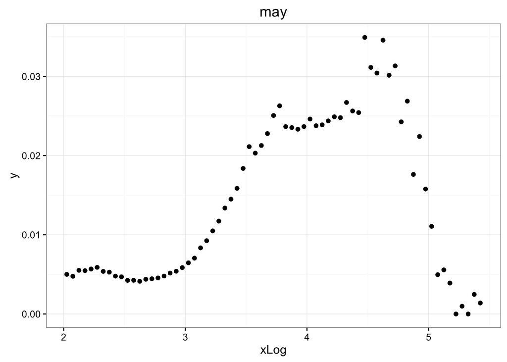

```
       x           y sample
1  2.025 0.005003259    may
2  2.075 0.004766040    may
3  2.125 0.005511215    may
4  2.175 0.005473518    may
5  2.225 0.005676796    may
6  2.275 0.005888514    may
7  2.325 0.005380965    may
8  2.375 0.005277277    may
9  2.425 0.004784754    may
10 2.475 0.004692053    may
11 2.525 0.004243139    may
12 2.575 0.004254570    may
13 2.625 0.004124148    may
14 2.675 0.004387725    may
```

[output cut: 55 more lines]

```r
> bc = read.table("cb-histogram.txt", header = FALSE, sep = "\t", nrows = 1e+05)
> bchead = head(bc, 1e+05)
> colnames(bc) = c("barcode", "count")
> allon_barcode_plot = function(bcs, sample) {
+     bcs_hist = hist(log10(bcs$count), plot = FALSE, n = 50)
+     fLog = bcs_hist$count
+     xLog = bcs_hist$mids
+     y = fLog * (10^xLog)/sum(fLog * (10^xLog))
+     print(qplot(xLog, y) + geom_point() + theme_bw() + ggtitle(sample))
+     return(data.frame(x = xLog, y = y, sample = sample))
+ }
> allon_barcode_plot(bc, "may")
```

We can see the same issue as before, there isn’t a clean peak like we saw with the K562 cells. We eventually landed on an explanation of free floating RNA due to cells dying being the culprit.

# Count based quality control

```r
> mart = useMart(biomart = "ENSEMBL_MART_ENSEMBL", dataset = "mmusculus_gene_ensembl",
+     host = "jul2015.archive.ensembl.org")
> conversions = getBM(attributes = c("ensembl_gene_id", "refseq_mrna", "ensembl_transcript_id",
+     "mgi_symbol"), mart = mart)
> load_counts = function(count_file) {
+     counts = read.table(count_file, header = TRUE, sep = ",")
+     counts = counts %>% tidyr::separate(gene, into = c("transcript", "version"),
+         sep = "\\.", fill = "right") %>% dplyr::left_join(conversions, c(transcript = "ensembl_transcript_id")) %>%
+         dplyr::filter(mgi_symbol != "") %>% dplyr::select(-transcript, -version,
+         -ensembl_gene_id, -refseq_mrna) %>% tidyr::gather(cell, count, -mgi_symbol) %>%
+         dplyr::group_by(cell, mgi_symbol) %>% dplyr::summarise(counts = sum(count)) %>%
+         tidyr::spread(cell, counts, fill = 0)
+     counts = as.data.frame(counts)
+     rownames(counts) = counts$mgi_symbol
+     counts$mgi_symbol = NULL
+     return(counts)
+ }
> counts = load_counts("may.counts")
```

# Count based quality control

## Genes Detected

Here we can see a bimodal distribution in genes detected, with some cells with a very small number of genes detected. We can see even the high end of the distribution only has a small number of genes detected < 1000.

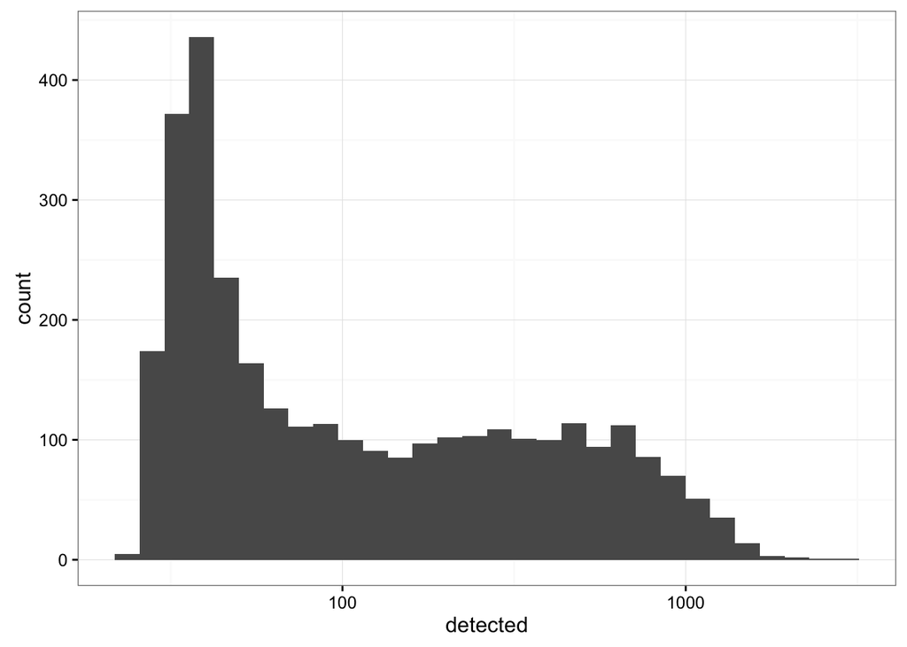

```r
> gd = data.frame(cell = colnames(counts), total = colSums(counts), detected = colSums(counts >
+     0), sample = "may")
> ggplot(gd, aes(detected)) + geom_histogram() + theme_bw() + scale_x_log10()
```

## Complexity

There are some cells that have a high number of counts but a low number of genes detected, these probably represent libraries with low complexity.

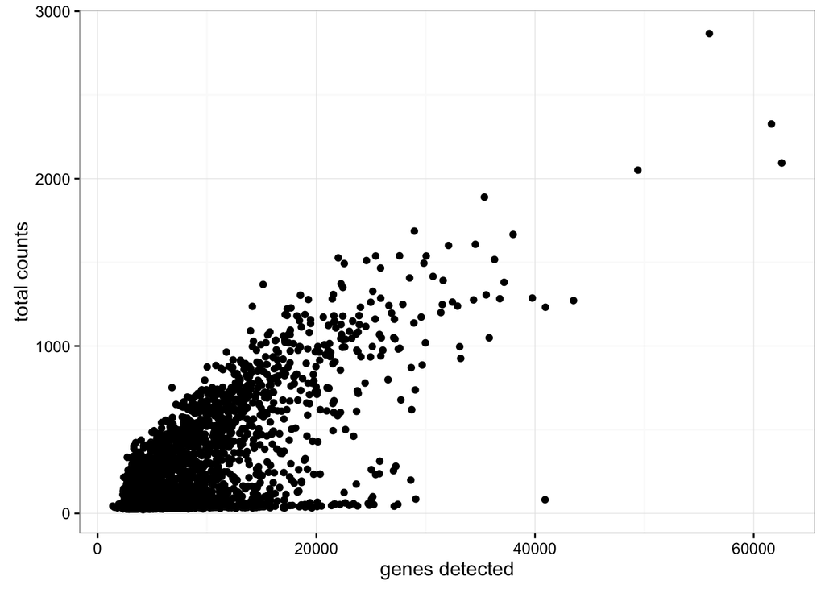

```r
> ggplot(gd, aes(total, detected)) + geom_point() + theme_bw() + xlab("genes detected") +
+     ylab("total counts")
```

## Subset cells

```r
> counts = counts[, subset(gd, detected > 500)$cell]
```

## Number of cells genes are expressed

Here again we can see that only a small number of genes are detected in the majority of the cells. Most genes are detected in < 100 of the cells.

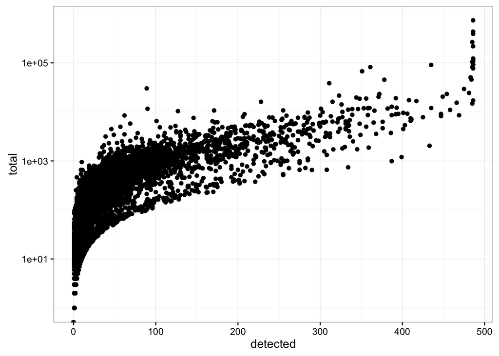

```r
> cpg = data.frame(gene = rownames(counts), total = rowSums(counts), detected = rowSums(counts >
+     0))
> ggplot(cpg, aes(detected, total)) + geom_point() + scale_y_log10() + theme_bw()
```

## Heatmap of top 200 expressed genes

This heatmap looks a little bit better than what we had before, but still isn’t great considering these are the genes with the highest counts.

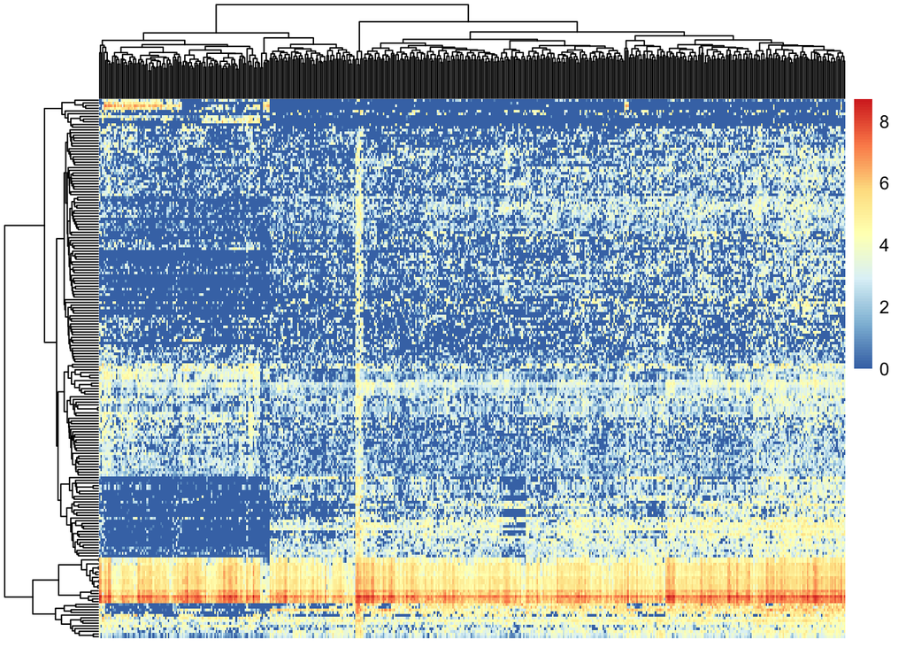

```r
> top_200_heatmap = function(counts) {
+     counts = as.matrix(counts)
+     counts = head(counts[order(rowSums(counts), decreasing = TRUE), ], 200)
+     pheatmap(log(counts + 1), show_rownames = FALSE, show_colnames = FALSE)
+ }
> top_200_heatmap(counts)
```

## Most variable genes

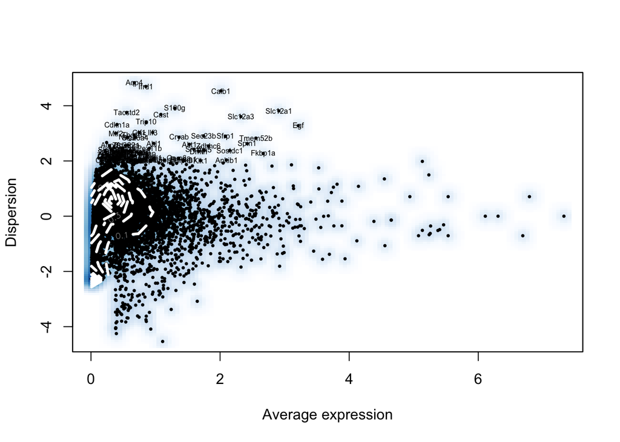

```r
> library(Seurat)
> counts.dat = counts
> colnames(counts.dat) = paste(colnames(counts.dat), "counts", sep = "_")
> counts.seurat = new("seurat", raw.data = log(counts.dat + 1))
> counts.seurat = setup(counts.seurat, project = "counts", min.cells = 3, min.genes = 500,
+     is.expr = 0.01, names.field = 2, names.delim = "_")
> counts.seurat = mean.var.plot(counts.seurat, y.cutoff = 2, do.plot = TRUE, x.low.cutoff = 0.25,
+     x.high.cutoff = 7, fxn.x = expMean, fxn.y = logVarDivMean)
```

```r
> counts.seurat@var.genes
```

```
 [1] "2010111I01Rik" "Abl1"          "Ackr3"         "AI846148"
 [5] "Akt1"          "Ankib1"        "Api5"          "Aqp4"
 [9] "Aqp6"          "Atp6v0d2"      "Brcc3"         "Calb1"
[13] "Car3"          "Cast"          "Cdkn1a"        "Cebpb"
[17] "Celsr2"        "Ciart"         "Cmpk2"         "Col27a1"
[21] "Cpsf1"         "Crtap"         "Cryab"         "Csnk1e"
[25] "Ctf1"          "Cyp7b1"        "Daam1"         "Dapk1"
[29] "Dmtn"          "Dpm2"          "Egf"           "Enox2"
[33] "Enpp1"         "Fign"          "Fkbp1a"        "Fmo5"
[37] "Gpm6a"         "Hipk3"         "Ifrd1"         "Ilf3"
[41] "Insrr"         "Irx1"          "Ispd"          "Klk1"
[45] "Ldlr"          "Ldlrad3"       "Lrrc1"         "Mospd3"
[49] "Mtf2"          "Nras"          "Nrf1"          "Nsg2"
[53] "Nudcd1"        "Nup98"         "Pak1ip1"       "Patl1"
[57] "Pex11b"        "Ppp2r2a"       "Pygo2"         "Rbbp5"
[61] "S100g"         "Sec23b"        "Sept6"         "Sfmbt1"
[65] "Sfrp1"         "Slc10a7"       "Slc12a1"       "Slc12a3"
[69] "Slc26a4"       "Smc5"          "Snhg11"        "Sostdc1"
[73] "Sox4"          "Sp1"           "Spin1"         "Srsf7"
[77] "Tacstd2"       "Tbc1d5"        "Tmem52b"       "Trip10"
[81] "Tsc2"          "Tubgcp2"       "Zdhhc6"        "Zfp322a"
[85] "Zfp839"
```

## PCA

It does kind of look like there are two populations of cells in these samples.

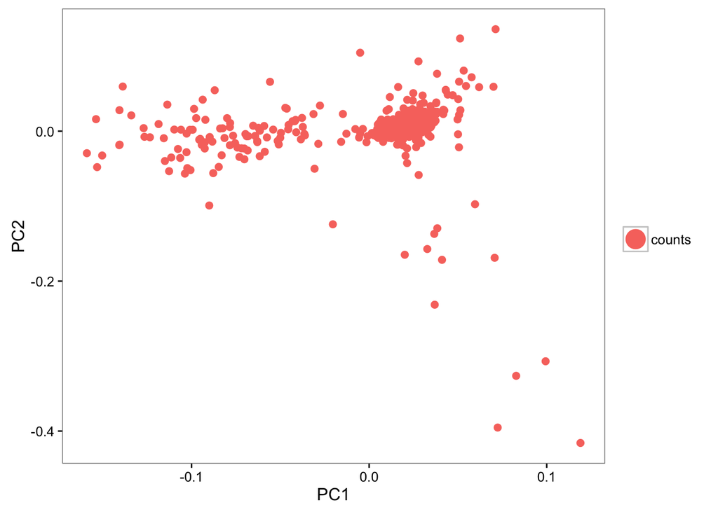

```r
> counts.seurat = pca(counts.seurat, pcs.print = 3, genes.print = 5, do.print = FALSE)
> pca.plot(counts.seurat, pt.size = 2)
```

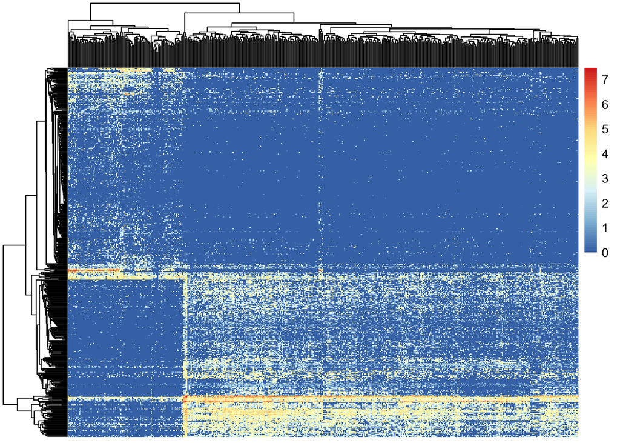

```r
> counts.seurat = project.pca(counts.seurat, do.print = FALSE)
> loadings = counts.seurat@pca.x.full
> top = loadings[, 1]
> names(top) = rownames(loadings)
> top = top[order(abs(top), decreasing = TRUE)][1:500]
> pheatmap(log(counts[names(top), ] + 1), show_rownames = FALSE, show_colnames = FALSE)
```

## Housekeeping genes

I pulled a set of housekeeping genes from [Evidence Based Selection of Housekeeping Genes](http://journals.plos.org/plosone/article?id=10.1371/journal.pone.0000898) and converted them to human and mouse symbols.

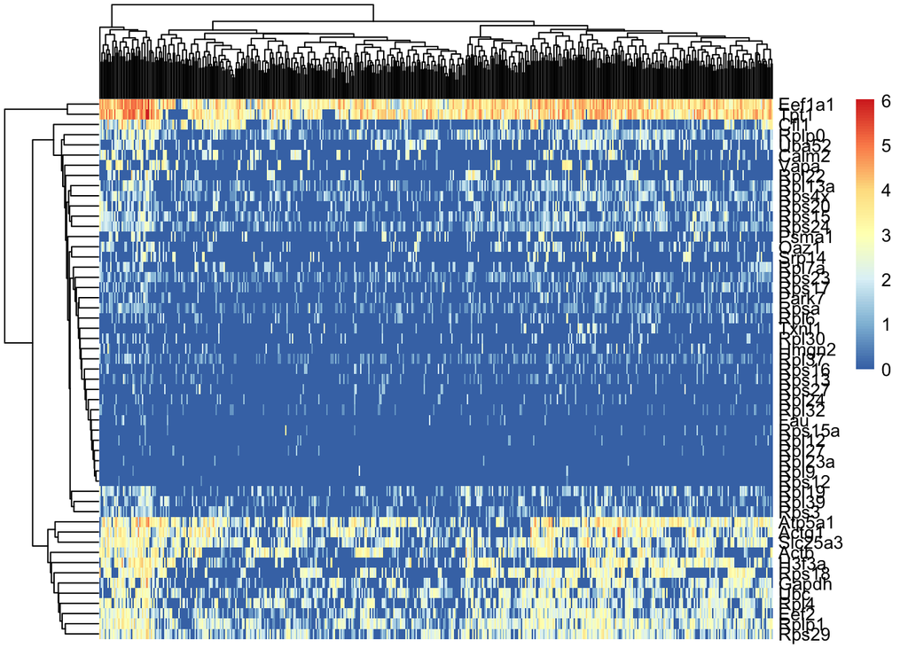

```r
> hk = as.character(read.table("../proximal-tubulue/metadata/hk.txt", header = FALSE)[,
+     "V1"])
> hk = c(hk, c("Actb", "Gapdh"))
> housekeeping_heatmap = function(counts, hk) {
+     counts = counts[rownames(counts) %in% hk, ]
+     pheatmap(log(counts + 1), show_rownames = TRUE, show_colnames = FALSE)
+ }
> housekeeping_heatmap(counts, hk)
```

## Marker genes

```r
> proximal = c("Gpx3", "Tnip1", "Hrsp12", "Hpd", "Hao2", "Ccdc152", "Apom", "Tmem27")
> henle = c("Spp1", "Cryab", "Ctsl1", "S100a1", "S100a6", "Aqp1", "Timp3")
> distal = c("Map3k7", "Atp1a", "Wfdc2", "Dnase1", "Degs2", "Ly6i", "Ctsd", "Tmem52b")
```

These markers show up in our list of the 500 highest weighted genes in PC1, and they are weighted in ways we might expect. The proximal genes have positive PC1 weightings, the distal genes have negative PC1 weightings and the Henle markers are mixed in PC1 and PC2.

```r
> inprox = top[names(top) %in% proximal]
> indist = top[names(top) %in% distal]
> inhenle = top[names(top) %in% henle]
> anno_row = data.frame(marker = "proximal", id = names(inprox))
> anno_row = rbind(anno_row, data.frame(marker = "distal", id = names(indist)))
> anno_row = rbind(anno_row, data.frame(marker = "henle", id = names(inhenle)))
> rownames(anno_row) = anno_row$id
> anno_row = anno_row[, "marker", drop = FALSE]
```

It looks like there could be more proximal cells than other cells based on those markers:

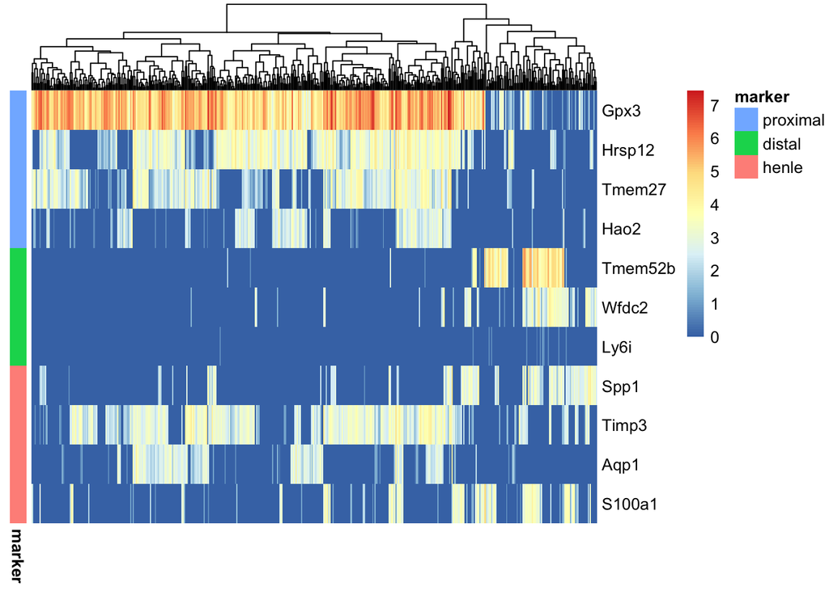

```r
> marker_heatmap = function(counts, anno_row) {
+     counts = counts[rownames(anno_row), ]
+     pheatmap(log(counts + 1), show_rownames = TRUE, show_colnames = FALSE, cluster_rows = F,
+         annotation_row = anno_row)
+ }
> marker_heatmap(counts, anno_row)
```

# Summary

We’ll stop for now, but it does look like there could be different populations of cells in this dataset, despite the quality issues.